# Simple analysis for Twitter Data

Let’s examine this object a bit for the sake of curiosity and better understanding

```r
typeof(gg)
```

```
## [1] "list"
```

```r
class(gg)
```

```
## [1] "gg"     "ggplot"
```

The `class` of an object is what make object-oriented programming possible in R and developers can assign peculiar behaviours to an object. This is the secret behind the *ggplot2* package.

This object `gg` contains a whole lot of information including our dataset, layers, scales, mapping, theme, coordinates, etc.

```r
str(gg)
```

```
## List of 9
##  $ data       :'data.frame': 500 obs. of  16 variables:
##   ..$ text         : chr [1:500] "¡Academia Japonia tendrá stand en el Salón del Manga de Barcelona! Tendremos mucha información para vosotros. <"| __truncated__ "Just watched @Xavi_Bove's webinar replay for @SBI_Barcelona very interesting presentation and a lot to learn fr"| __truncated__ "Barce…
##   ..$ favorited    : logi [1:500] FALSE FALSE FALSE FALSE FALSE FALSE ...
##   ..$ favoriteCount: num [1:500] 0 0 0 0 0 0 0 0 0 0 ...
##   ..$ replyToSN    : chr [1:500] NA NA NA NA ...
##   ..$ created      : POSIXct[1:500], format: "2017-10-11 15:09:20" ...
##   ..$ truncated    : logi [1:500] TRUE FALSE FALSE FALSE FALSE FALSE ...
##   ..$ replyToSID   : chr [1:500] NA NA NA NA ...
##   ..$ id           : chr [1:500] "918131407398096896" "918131405678436352" "918131405271351296" "918131403086327809" ...
##   ..$ replyToUID   : chr [1:500] NA NA NA NA ...
##   ..$ statusSource : chr [1:500] "<a href=\"http://twitter.com\" rel=\"nofollow\">Twitter Web Client</a>" "<a href=\"http://twitter.com\" rel=\"nofollow\">Twitter Web Client</a>" "<a href=\"https://dlvrit.com/\" rel=\"nofollow\">dlvr.it</a>" "<a href=\"http://twitter.com/download/android\" rel=\"…
##   ..$ screenName   : chr [1:500] "academiajaponia" "HaimovichDavid" "LFC_SC" "oscarlena1992" ...
##   ..$ retweetCount : num [1:500] 0 0 0 1134 0 ...
##   ..$ isRetweet    : logi [1:500] FALSE FALSE FALSE TRUE FALSE TRUE ...
##   ..$ retweeted    : logi [1:500] FALSE FALSE FALSE FALSE FALSE FALSE ...
##   ..$ longitude    : chr [1:500] NA NA NA NA ...
##   ..$ latitude     : chr [1:500] NA NA NA NA ...
##  $ layers     : list()
##  $ scales     :Classes 'ScalesList', 'ggproto' <ggproto object: Class ScalesList>
##     add: function
##     clone: function
##     find: function
##     get_scales: function
##     has_scale: function
##     input: function
##     n: function
##     non_position_scales: function
##     scales: NULL
##     super:  <ggproto object: Class ScalesList>
##  $ mapping    : list()
##  $ theme      : list()
##  $ coordinates:Classes 'CoordCartesian', 'Coord', 'ggproto' <ggproto object: Class CoordCartesian, Coord>
##     aspect: function
##     distance: function
##     expand: TRUE
##     is_linear: function
##     labels: function
##     limits: list
##     range: function
```

[output cut: 17 more lines]

```
##     params: list
##     render_back: function
##     render_front: function
##     render_panels: function
##     setup_data: function
##     setup_params: function
##     shrink: TRUE
##     train: function
##     train_positions: function
##     train_scales: function
##     vars: function
##     super:  <ggproto object: Class FacetNull, Facet>
##  $ plot_env   :<environment: R_GlobalEnv>
##  $ labels     : list()
##  - attr(*, "class")= chr [1:2] "gg" "ggplot"
```

Now we’re going to introduce the aesthetics function `aes()`, which is necessary to map variables from the dataset to parts of the plotting area.

To quickly demonstrate what this function does, check this out

```r
aes(created)
```

```
## * x -> created
```

The above output shows that we are mapping our *created* variable to the x-axis of our plot, as can be seen below…

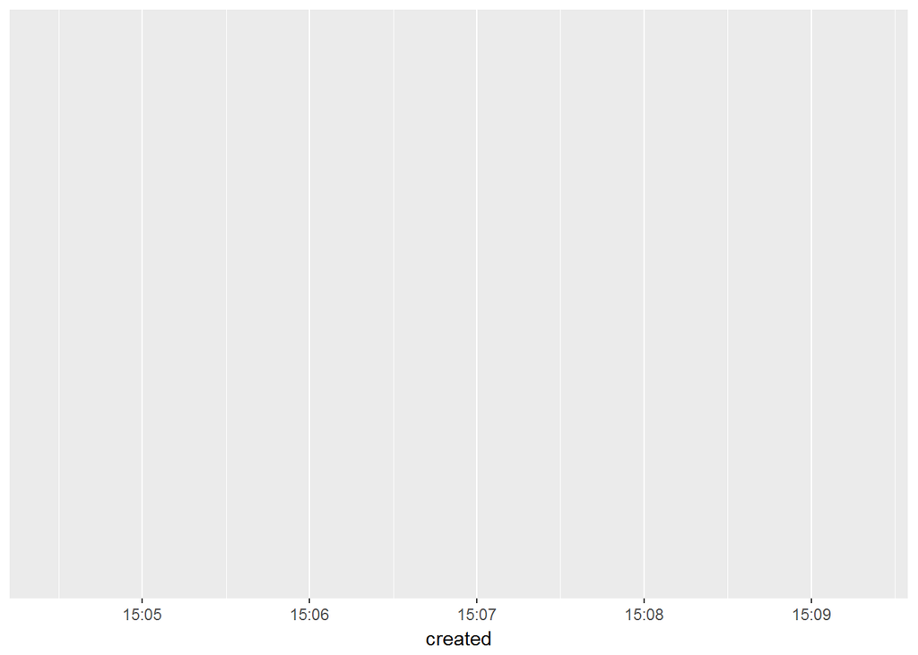

```r
gg <- ggplot(tweets, aes(created))
gg
```

We will now draw a simple graph of our tweets based on when they were created, precisely a density plot using `geom_density()`

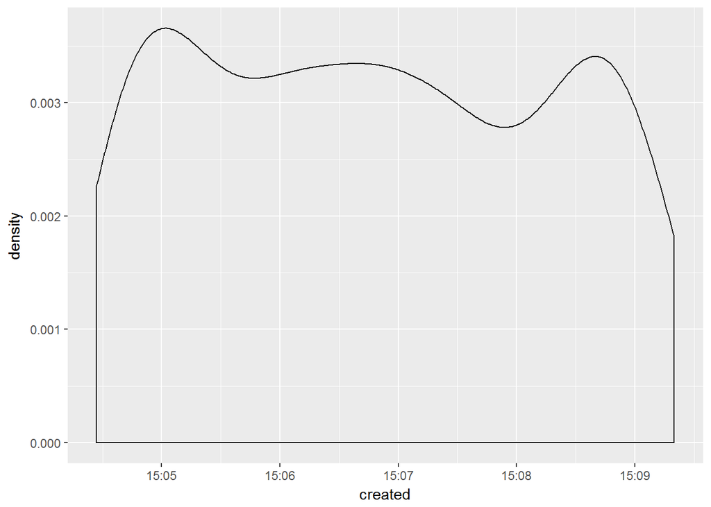

```r
ggplot(tweets, aes(created)) +
  geom_density()
```

The `+` sign tells us that we are adding this on top of our plotting area as a layer. In the *ggplot2* package, you can add various elements of a plot one on top of another in this way, but we will not go into that here.

Now, we would like to explore the data in a multivariate fashion. We can check to see how different categories of tweets are distributed e.g. whether they are retweets or not (comparing `created` with `isRetweet` variable). We will do this by mapping another aesthetic, not to an axis, but to a colour scheme - by applying this to function that created the curve in the first place.

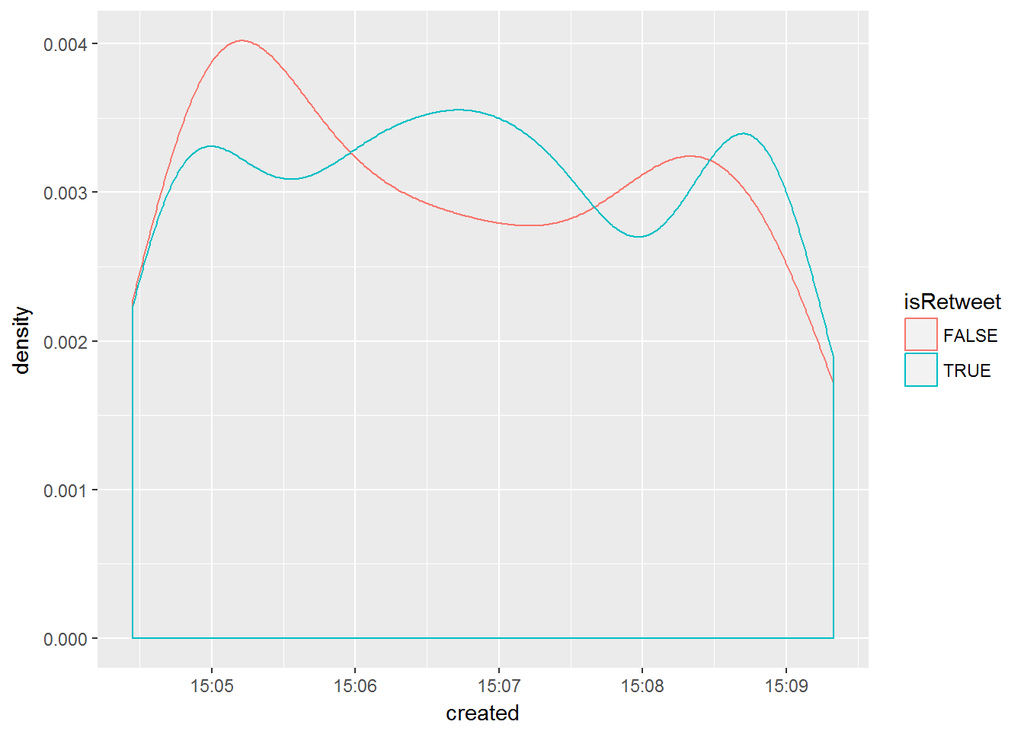

```r
gg <- ggplot(tweets, aes(created)) +
  geom_density(aes(col = isRetweet))
gg
```

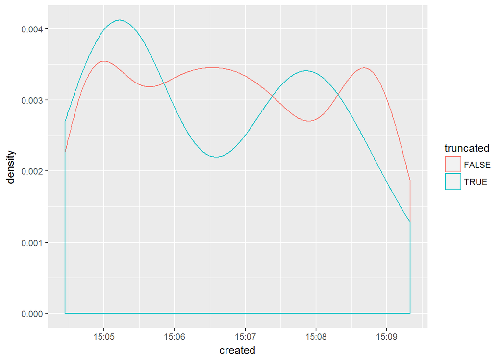

```r
gg <- ggplot(tweets, aes(created)) +
  geom_density(aes(col = truncated))
gg
```

```r
gg <- ggplot(tweets, aes(created)) +
  geom_density(aes(fill = isRetweet))
```

Now include some transparency using the **alpha** parameter

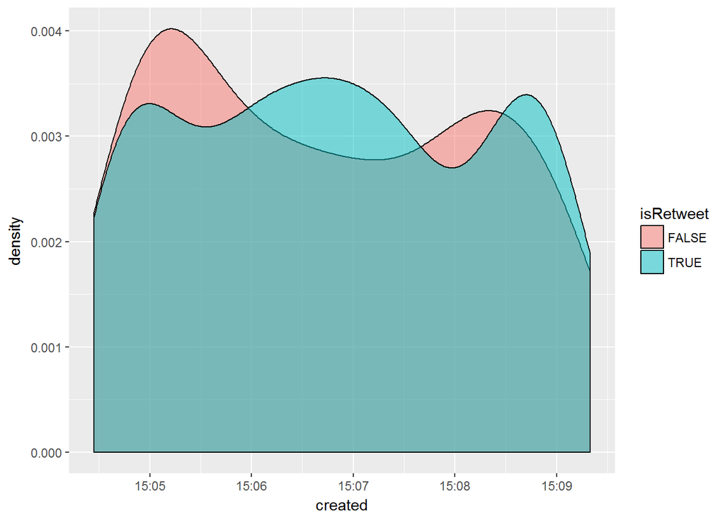

```r
ggplot(tweets, aes(created)) +
  geom_density(aes(fill = isRetweet), alpha = 0.5)
```